# SF Vignette - SATSA simulation

Glen Pridham 2023 Rutengroup

Tutorial on using sf.R. SF: stochastic finite model.

Purpose: demonstrate how to simulate data from SATSA (Swedish Adoption/Twin Study - “twins”), including interventions.

The SATSA data includes initial age and sex, which we will include. We provide data only for simulating starting from age 60.

SATSA data are longitudinal biological age measurements. See readme for reference.

```r
#load in sf.R
outputDir = ""  #enter the file location for sf.R
source(sprintf("%s/sf.R",outputDir))
```

# Load parameters

We need: 1. the model parameters: a) interaction network, b) equilibrium positions, and c) noise. 2. realistic starting values: a) mean for each sex, and b) covariance for each sex.

Model parameters

```r
W = read.csv(sprintf("%s/twins_W_lm_v2.csv",outputDir),row.names=1) #W estimated using linear model (lm) and pre-processed using PCA (v2)
lambda = read.csv(sprintf("%s/twins_lambda_lm_v2.csv",outputDir),row.names=1)
Q = read.csv(sprintf("%s/twins_Q_lm_v2.csv",outputDir),row.names=1) #Q is inverse dynamical covariance ("precision matrix")
```

We have 8 variables, each on is a “biological age”, as can be seen by observing the network,

```r
round(W,2)
```

|  | telomere | dnamage_horvath | dnamage_hannum | dnamage_pheno | dnamage_grim | physio_age | cognition | fai |
| --- | --- | --- | --- | --- | --- | --- | --- | --- |
| telomere | -0.06 | 0.00 | 0.01 | 0.00 | -0.02 | 0.00 | 0.00 | -0.01 |
| dnamage_horvath | 0.00 | -0.07 | 0.00 | 0.00 | 0.02 | 0.03 | 0.00 | 0.00 |
| dnamage_hannum | 0.00 | 0.01 | -0.07 | 0.00 | 0.01 | 0.03 | 0.00 | 0.00 |
| dnamage_pheno | 0.00 | 0.01 | 0.00 | -0.08 | 0.02 | 0.04 | 0.00 | 0.01 |
| dnamage_grim | 0.00 | 0.00 | 0.00 | 0.00 | -0.04 | 0.03 | 0.00 | 0.00 |
| physio_age | 0.00 | 0.00 | 0.00 | 0.01 | 0.01 | -0.04 | 0.00 | 0.00 |
| cognition | 0.00 | -0.01 | 0.00 | 0.00 | -0.01 | -0.02 | -0.02 | 0.00 |
| fai | 0.00 | -0.01 | 0.01 | 0.00 | 0.04 | 0.04 | -0.02 | -0.07 |

We need starting values which we’ll sample from a multivariate Gaussian using the mean and covariance from SATSA for individuals between ages 55-65. We intend to simulate individuals of baseline age 60.

```r
vars = rownames(W)
#males
mum = read.csv(sprintf("%s/twins_male_donors_mean.csv",outputDir),row.names=1)[vars,1]
sigm = read.csv(sprintf("%s/twins_male_donors_cov.csv",outputDir),row.names=1)[vars,vars]

#females
muf = read.csv(sprintf("%s/twins_female_donors_mean.csv",outputDir),row.names=1)[vars,1]
sigf = read.csv(sprintf("%s/twins_female_donors_cov.csv",outputDir),row.names=1)[vars,vars]
```

# Setup simulation parameters

```r
set.seed(42) #for reproducibility

#Step 1. How many males/females do you want?
Nm = 500
Nf = 500

#Step 2. how many timesteps do you want to take? (can be uniform or non, will specify in step 5)
times = 60

#Step 3. sample starting points
ym = mvrnorm(n=Nm,mu=mum,Sigma=sigm)
yf = mvrnorm(n=Nf,mu=muf,Sigma=sigf)
y0 = rbind(ym,yf)

#Step 4. prep covariates
#sex and intercept
x = array(NA,c(nrow(y0),ncol(lambda),times))
colnames(x) = colnames(lambda)
x[,"mu0",] = 1 #intercept
x[,"sex",] = c(rep(0,Nm),rep(1,Nf)) #0: male, 1: female


#Step 5. pick timesteps
dt = matrix(1,nrow=nrow(y0),ncol=times-1)
age = array(60,c(nrow(y0),times))
for (k in 2:dim(age)[2]) age[,k] = age[,k-1]+dt[,k-1]


#Step 6. noise
noiseCov = solve(Q) #stepper takes inverse of Q

#Step 7. Now we're ready to simulate!
```

# Now we’re ready to simulate

```r
sim = Sim.SF(N=Nm+Nf,x=x,lambda=lambda,W=W,times=times,dt=dt,noiseCov=noiseCov,
            mu0=rep(0,ncol(y0)), #intercept can be specified here, but we used x[mu0] instead
            y0 = y0
            )
```

Sim.SF simulates multivariate trajectories for each individual in y, then returns the parameters

```r
print(names(sim))
```

```
 [1] "y"        "x"        "mu0"      "p"        "N"        "W"        "dt"       "times"    "noiseCov" "lambda"   "mu0i"
```

```r
str(sim$y)
```

```
 num [1:1000, 1:8, 1:60] 81.3 76.3 73.5 78.2 70.5 ...
 - attr(*, "dimnames")=List of 3
  ..$ : NULL
  ..$ : chr [1:8] "telomere" "dnamage_horvath" "dnamage_hannum" "dnamage_pheno" ...
  ..$ : NULL
```

As you can see y is a 3d array of individuals x variables x times.

We see that the mean of each variable drifts with age.

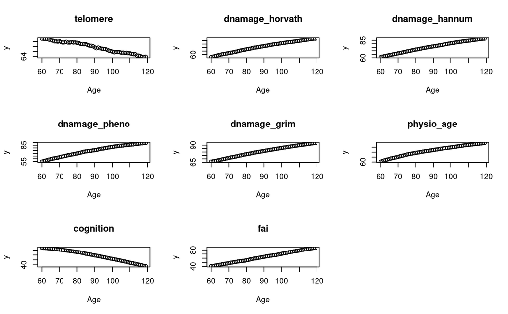

```r
par(mfrow=c(3,3)) #for multiple plots on same canvas
for (i in 1:ncol(sim$y)) plot(apply(age,2,mean),apply(sim$y[,i,],2,mean),main=colnames(sim$y)[i],ylab="y",xlab="Age")
```

We can also look at individual trajectories, say individual 1

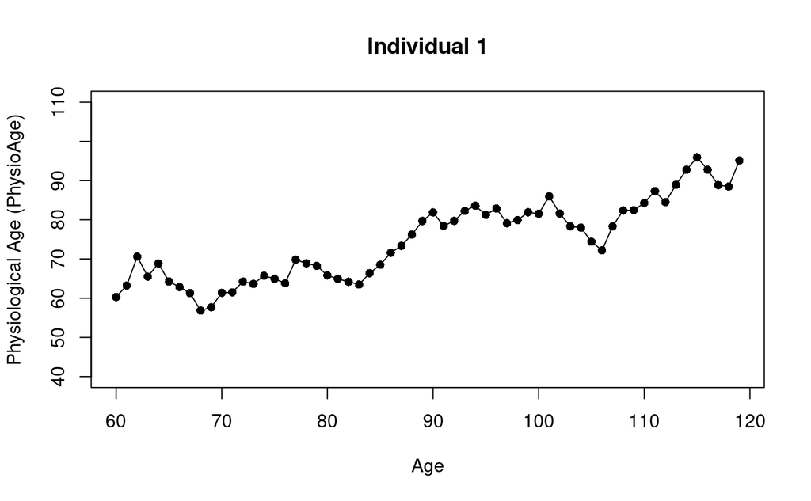

```r
plot(age[1,],sim$y[1,"physio_age",],xlab="Age",ylab="Physiological Age (PhysioAge)",main="Individual 1",pch=16,ylim=c(40,110))
lines(age[1,],sim$y[1,"physio_age",],xlab="Age",ylab="Physiological Age (PhysioAge)",main="Individual 1")
```

Physiological Age (PhysioAge) is a measure of health as quantified as an effective age in years (a PhysioAge of 80 implies you have the physiology of an 80 year-old). As we see, the simulation thinks it should increase roughly linearly with age starting around age 70, but with non-trivial stochasticity.

What happens if we intervene on PhysioAge?

# Intervention simulation

We see how the natural population behaves without intervention. What if we intervene with an anti-aging treatment that rejuvenates physiological age?

Sim.SF permits impulse (delta function) interventions which instantaneously rejuvenate each individual at a specified time, applied to each specified variable.

We already have the control data from earlier but now we need some case data. We can match case and control perfectly by setting the same seeds or we can be imprecise about case and control, instead matching by age and sex.

```r
match=T #do you want to perfectly match case and control (including stochastic events)?
if(match) set.seed(42)

#step 1. resample starting points
ymcase = mvrnorm(n=Nm,mu=mum,Sigma=sigm)
yfcase = mvrnorm(n=Nf,mu=muf,Sigma=sigf)
y0case = rbind(ymcase,yfcase)

#step 2. set intervention, scale is in years
#we need to specify when (index) and how big of an effect
interventionTime = round(10/mean(dt))+1 #we want to intervene 10 years into the simulation
#the intervention is a vector of values, one for each variable
intervention = rep(0,ncol(y0case))
names(intervention) = colnames(y0case)
intervention[["physio_age"]] = -10 #we want to rejuvenate (make younger) PhysioAge by 10 years


case = Sim.SF(N=Nm+Nf,x=x,lambda=lambda,W=W,times=times,dt=dt,noiseCov=noiseCov,
            mu0=rep(0,ncol(y0)), #intercept can be specified here, but we used x[mu0] instead
            y0 = y0,
            interventionTime=interventionTime,intervention=intervention
            )
```

So what happens to PhysioAge?

```r
plot(age[1,],sim$y[1,"physio_age",],xlab="Age",ylab="Physiological Age (PhysioAge)",main="Individual 1",pch=16,ylim=c(40,110))
lines(age[1,],sim$y[1,"physio_age",],xlab="Age",ylab="Physiological Age (PhysioAge)",main="Individual 1")
```

```r
points(age[1,],case$y[1,"physio_age",],pch=17,col=2)
lines(age[1,],case$y[1,"physio_age",],col=2,lty=2)
```

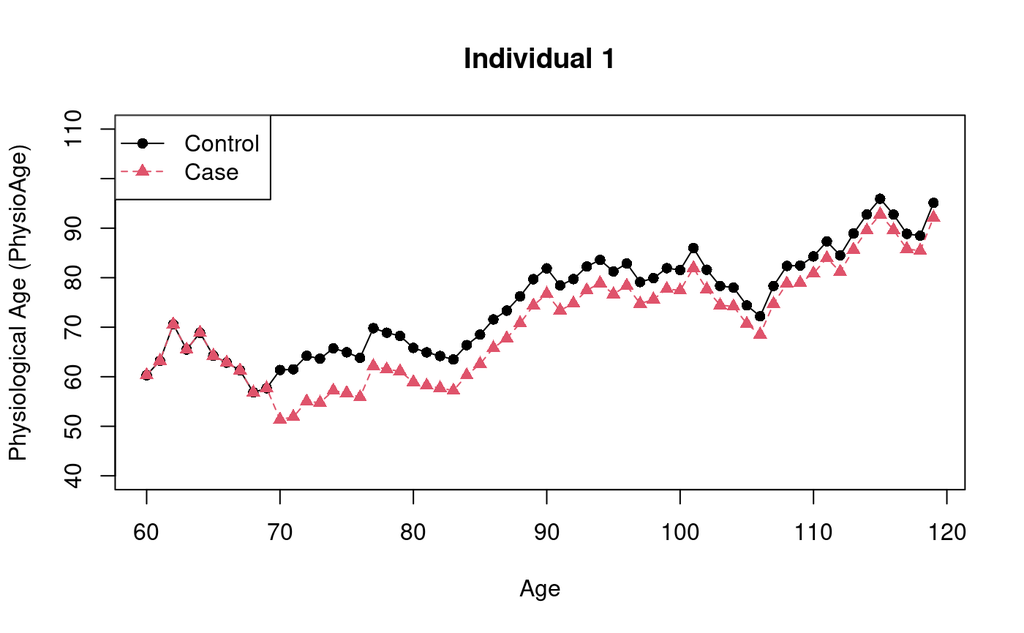

```r
legend("topleft",c("Control","Case"),col=1:2,pch=1:2+15,lty=1:2)
```

We can subtract case from control to get an idea of the overall effect on each variable

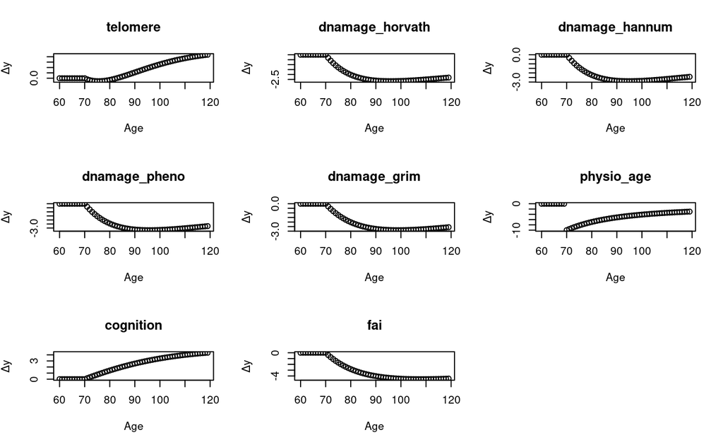

```r
par(mfrow=c(3,3)) #for multiple plots on same canvas
for (i in 1:ncol(sim$y)) plot(apply(age,2,mean),apply(case$y[,i,],2,mean)-apply(sim$y[,i,],2,mean),main=colnames(sim$y)[i],ylab=bquote(Delta*y),xlab="Age")
```

We see that PhysioAge improves immediately at age 70, this is because we defined the intervention as such. The other variables show delayed effects, however, and telomere actually changes directions: going down between ages 70-80 then up. This delayed an unusual behaviour is due to the network of interactions.

The rejuvenation impulse perturbs PhysioAge then the network adjusts each other variable to compensate, causing information to bounce around.

It may interest you to try more complex interventions, such as improving multiple variables at once.

# What if we improve each variable all at once?

Suppose we instead intervene simultaneously on all variables, improving them all by 10 years.

```r
match=T #do you want to perfectly match case and control?
if(match) set.seed(42)

#step 1. resample starting points
ymcase = mvrnorm(n=Nm,mu=mum,Sigma=sigm)
yfcase = mvrnorm(n=Nf,mu=muf,Sigma=sigf)
y0case = rbind(ymcase,yfcase)

#step 2. set intervention, scale is in years
#we need to specify when (index) and how big of an effect
interventionTime = 10/mean(dt)+1 #we want to intervene 10 years into the simulation
#the intervention is a vector of values, one for each variable
intervention = rep(-10,ncol(y0case))
names(intervention) = colnames(y0case)
#two of the variables have opposite 'risk' directions (worse health)
intervention[["telomere"]] = 10
intervention[["cognition"]] = 10


case = Sim.SF(N=Nm+Nf,x=x,lambda=lambda,W=W,times=times,dt=dt,noiseCov=noiseCov,
            mu0=rep(0,ncol(y0)), #intercept can be specified here, but we used x[mu0] instead
            y0 = y0,
            interventionTime=interventionTime,intervention=intervention
            )
```

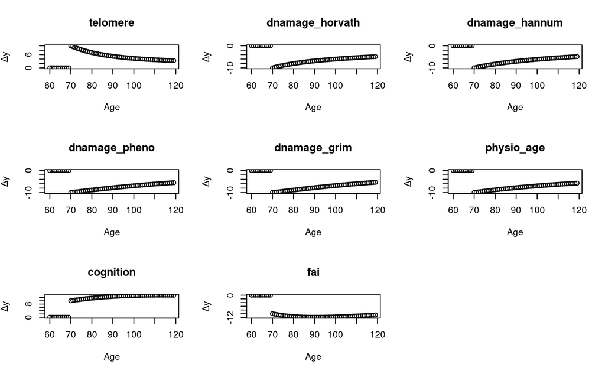

```r
par(mfrow=c(3,3)) #for multiple plots on same canvas
for (i in 1:ncol(sim$y)) plot(apply(age,2,mean),apply(case$y[,i,],2,mean)-apply(sim$y[,i,],2,mean),main=colnames(sim$y)[i],ylab=bquote(Delta*y),xlab="Age")
```

Looks a little boring. This could be because we’ve stimulated one of the normal modes (eigenvectors / natural variables), which have simple dynamics. See the natural variables vignette for more information.